# #Python Project 04

Q1. Import required libraries and read the dataset.

```python
import numpy as np
import pandas as pd
import matplotlib.pyplot as plt
import seaborn as sns
```

```python
data=pd.read_csv("honeyproduction.csv")
```

Q2) Check the first few samples, shape, info of the data and try to familiarize yourself with different features

```python
data.sample(5)
```

|  | state | numcol | yieldpercol | totalprod | stocks | priceperlb | prodvalue | year |
| --- | --- | --- | --- | --- | --- | --- | --- | --- |
| 177 | CO | 24000.0 | 60 | 1440000.0 | 576000.0 | 1.29 | 1858000.0 | 2002 |
| 495 | PA | 21000.0 | 40 | 840000.0 | 319000.0 | 2.03 | 1705000.0 | 2009 |
| 420 | VA | 6000.0 | 46 | 276000.0 | 63000.0 | 2.43 | 671000.0 | 2007 |
| 332 | PA | 28000.0 | 56 | 1568000.0 | 800000.0 | 1.12 | 1756000.0 | 2005 |
| 513 | HI | 10000.0 | 77 | 770000.0 | 239000.0 | 2.75 | 2118000.0 | 2010 |

```python
data.shape
```

```
(626, 8)
```

```python
data.info()
```

```
<class 'pandas.core.frame.DataFrame'>
RangeIndex: 626 entries, 0 to 625
Data columns (total 8 columns):
 #   Column       Non-Null Count  Dtype
---  ------       --------------  -----
 0   state        626 non-null    object
 1   numcol       626 non-null    float64
 2   yieldpercol  626 non-null    int64
 3   totalprod    626 non-null    float64
 4   stocks       626 non-null    float64
 5   priceperlb   626 non-null    float64
 6   prodvalue    626 non-null    float64
 7   year         626 non-null    int64
dtypes: float64(5), int64(2), object(1)
memory usage: 39.2+ KB
```

```python
data.head(5)
```

|  | state | numcol | yieldpercol | totalprod | stocks | priceperlb | prodvalue | year |
| --- | --- | --- | --- | --- | --- | --- | --- | --- |
| 0 | AL | 16000.0 | 71 | 1136000.0 | 159000.0 | 0.72 | 818000.0 | 1998 |
| 1 | AZ | 55000.0 | 60 | 3300000.0 | 1485000.0 | 0.64 | 2112000.0 | 1998 |
| 2 | AR | 53000.0 | 65 | 3445000.0 | 1688000.0 | 0.59 | 2033000.0 | 1998 |
| 3 | CA | 450000.0 | 83 | 37350000.0 | 12326000.0 | 0.62 | 23157000.0 | 1998 |
| 4 | CO | 27000.0 | 72 | 1944000.0 | 1594000.0 | 0.70 | 1361000.0 | 1998 |

```python
data.tail(5)
```

|  | state | numcol | yieldpercol | totalprod | stocks | priceperlb | prodvalue | year |
| --- | --- | --- | --- | --- | --- | --- | --- | --- |
| 621 | VA | 4000.0 | 41 | 164000.0 | 23000.0 | 3.77 | 618000.0 | 2012 |
| 622 | WA | 62000.0 | 41 | 2542000.0 | 1017000.0 | 2.38 | 6050000.0 | 2012 |
| 623 | WV | 6000.0 | 48 | 288000.0 | 95000.0 | 2.91 | 838000.0 | 2012 |
| 624 | WI | 60000.0 | 69 | 4140000.0 | 1863000.0 | 2.05 | 8487000.0 | 2012 |
| 625 | WY | 50000.0 | 51 | 2550000.0 | 459000.0 | 1.87 | 4769000.0 | 2012 |

Q3) Display the percentage distribution of the data in each year using the pie chart.

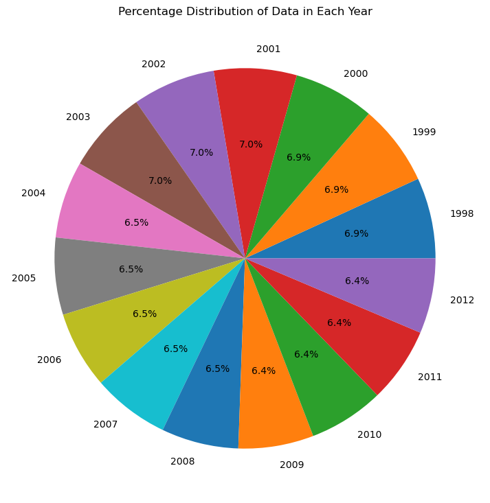

```python
year_perdist = data.groupby('year').size()/len(data)*100
plt.figure(figsize=(9,9))
plt.pie(year_perdist, labels=year_perdist.index, autopct='%1.1f%%')
plt.title('Percentage Distribution of Data in Each Year')
plt.show()
```

Q4. Plot and Understand the distribution of the variable "price per lb" using displot, and write your findings

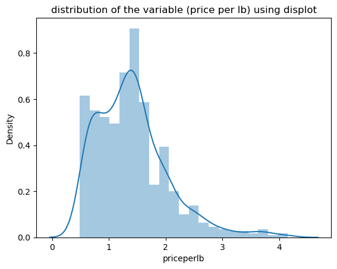

```python
sns.distplot(data['priceperlb'])
plt.title("distribution of the variable (price per lb) using displot")
plt.show()
```

Q5. Plot and understand the relationship between the variables 'numcol' and 'prodval' through scatterplot, and write your findings.

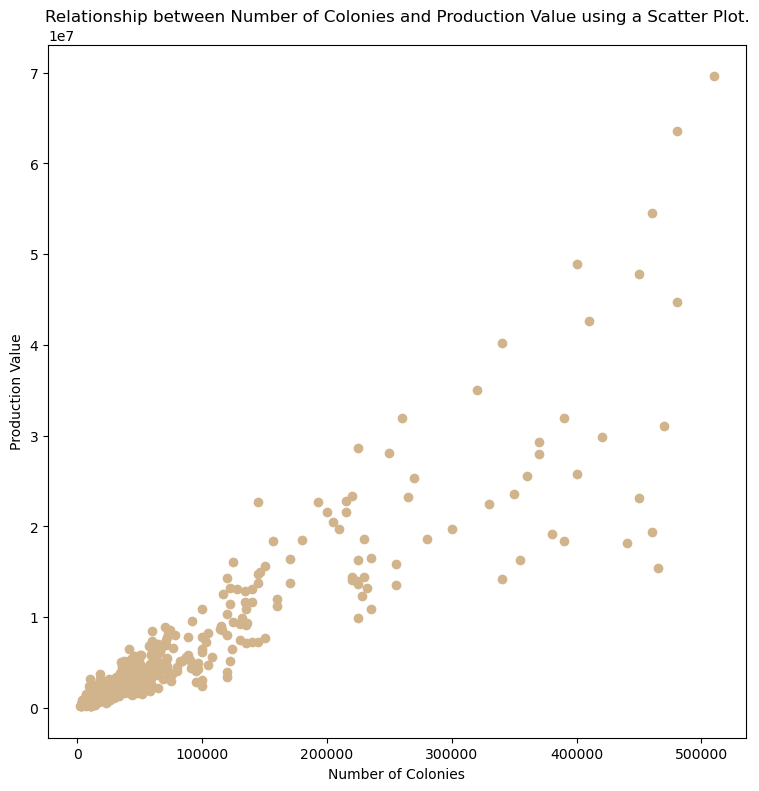

```python
plt.figure(figsize=(9,9))
plt.scatter(data['numcol'], data['prodvalue'],color = "tan")
plt.xlabel('Number of Colonies')
plt.ylabel('Production Value')
plt.title('Relationship between Number of Colonies and Production Value using a Scatter Plot.')
plt.show()
```

Q6. Plot and understand the relationship between categorical variable 'year' and a numerical variable 'prodvalue' through boxplot, and write your findings.

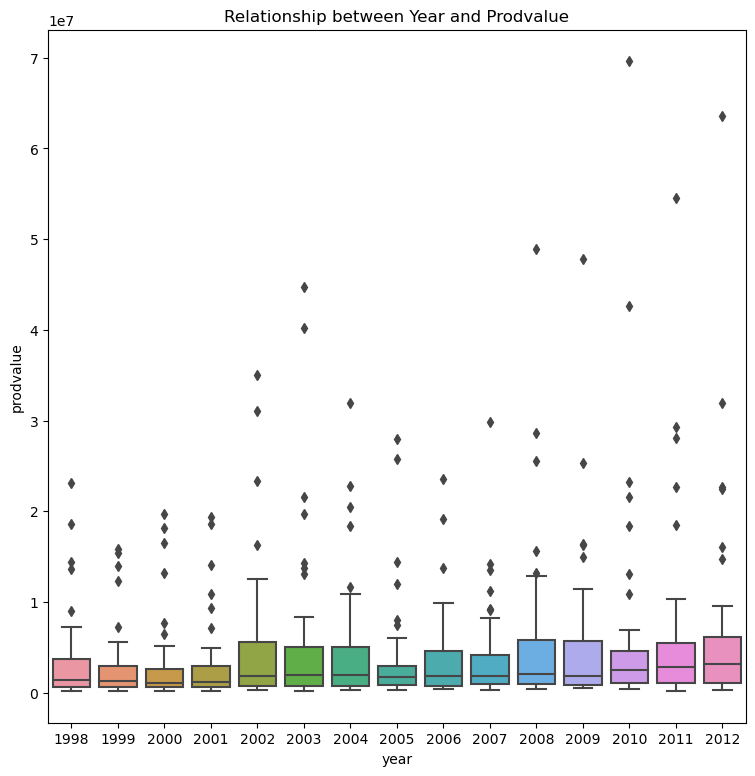

```python
plt.figure(figsize=(9,9))
sns.boxplot(x='year', y='prodvalue', data=data)
plt.title('Relationship between Year and Prodvalue')
plt.show()
```

Q7. Visualize and understand the relationship between the multiple pairs of variables throughout different years using pairplot and add your inferences. (use columns 'numcol', 'yield percol', 'total prod', 'prodvalue','year')

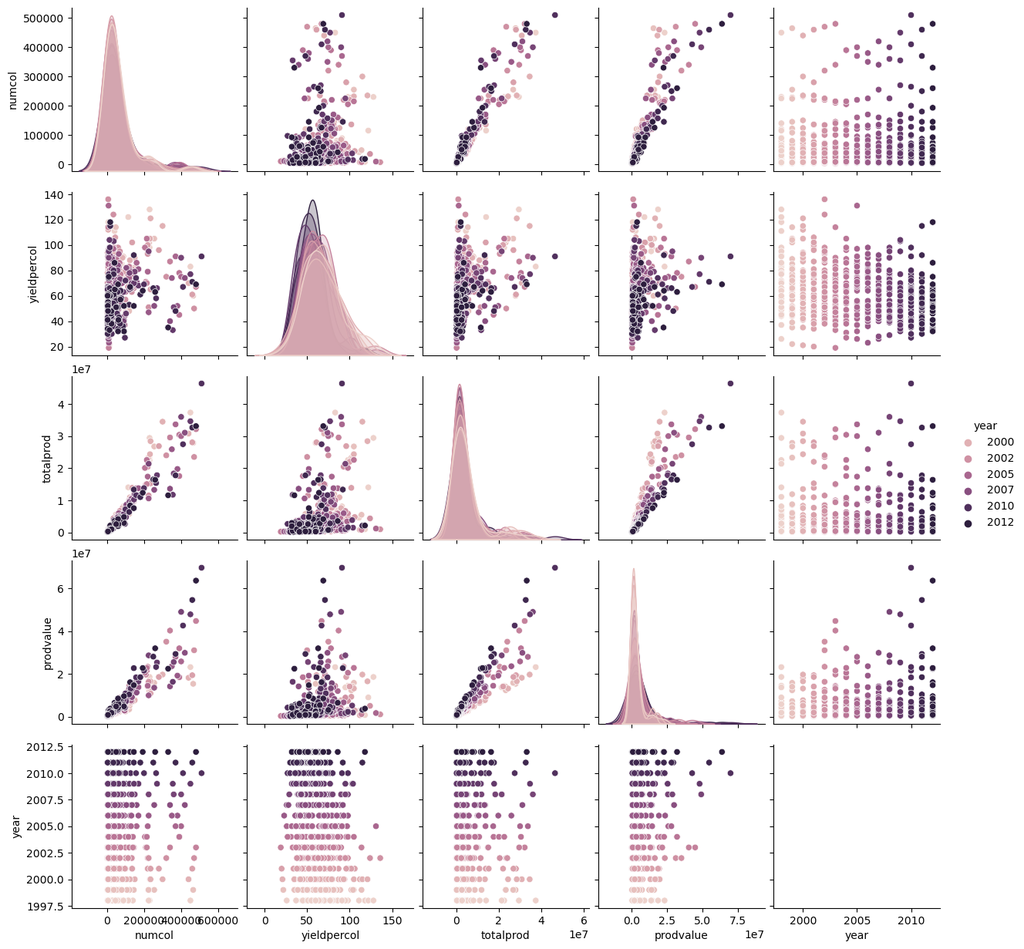

```python
sns.pairplot(data, vars=['numcol', 'yieldpercol', 'totalprod', 'prodvalue', 'year'], hue='year')
```

Q8. Display the correlation values using a plot and add your inferences. (use columns 'numcol', 'yield percol', 'total prod', 'stocks', 'price per lb', 'prodvalue')

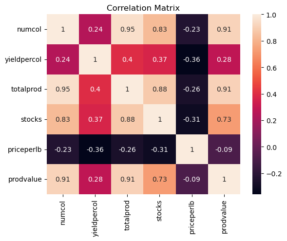

```python
data_subset = data[['numcol', 'yieldpercol', 'totalprod', 'stocks', 'priceperlb', 'prodvalue']]
corr_matrix = data_subset.corr()
sns.heatmap(corr_matrix, annot=True)
plt.title("Correlation Matrix")
plt.show()
```